# Technical Report: Team Project AAI 500

### *Introduction:*

This report presents an analysis of the wholesale data for a range of products. The objective is to understand the expenditure patterns of clients across different regions and product categories and to assist the stakeholders in understanding different metrics of the products being consumed. Furthermore, we elaborate on some startegies tom improve product sales, confidence intervals of the mean of the products being consumed and marketing suggestions.

### *Analysis 1-1 - 1-8:*

**1-3, 1-4:**

Region 3 has the highest total sales across all product categories at 73% of total sales. Focus marketing efforts here for its sales potential.. Region 1 has the second highest total sales at 16% of total sales. It should also receive marketing attention. Region 2 has the smallest share of total sales at 10%. It is a lower priority for marketing. Fresh and Grocery lead sales in all regions. Prioritize marketing campaigns toward these categories.

**1-6**

On average, customers spend the most on Fresh Food and Groceries. They spend a good amount on Milk and Frozen Food too. Marketing should focus more on these categories since customers buy them more. Customers buy very different amounts of each product. Some buy a lot, some buy only a little bit. Marketing should have offers for all customer groups - those who buy little, medium amounts, and large amounts. A small number of customers spend a huge amount in some categories. These customers are very valuable. The store should have special VIP rewards to keep these big spenders happy.

**1-8:**

The analysis shows a strong connection between spending on groceries and spending on detergents and paper products. Customers who put more in their grocery carts also tend to buy more laundry detergent, paper towels, and other cleaning supplies. This makes intuitive sense - the more you cook and prepare food at home, the more you need supplies to keep your home clean.

We also see that milk purchases are closely linked to grocery and detergent/paper spending. When customers buy more milk, they also spend more on other grocery staples and home cleaning products. Milk is a common purchase for most households, so higher milk spending likely indicates overall higher grocery spending.

Recommendations: Offer cross-promotions linking grocery and home cleaning staples to reflect how customers buy these together. For example, "Spend 50 M.U on Grocery and Get 5 M.U Off Detergent" Position milk where shoppers add a lot to their overall grocery carts.

### *Analysis 1-9 - 1-15*

**1-9 - 1-10:**

These two lines of code represent a subset of our data, in order to utilize the the columns in a more efficient way for the next blocks of codes we decided to drop channel and region columns.

**1-11 - 1-12:**

We created a function to plot and calculate the confidence intervals for the categories of products we wanted to analyze. On block 1-7 we saw the distributions of each of the products and resembled a gamma distribution, therefore in order to construct a sampling distribution of these categories we decided to use the Gamma function with their corresponding parameters to plot the sampling distribution a long with the confidence intervals to have an idea of where the mean of each of the products being sold was going to land. The block also plots the approximation of the probability density function of the product category to confirm that we are representing the original population distribution. The libraries we used were Seaborn, matplot.lib, Numpy, and Stats.Gamma. Customers' behaviors and product spending follow predictable patterns that can be modeled mathematically. This allows reliable sales predictions. The models show most customers spend around typical averages, but some spend much less, and some spend way more.

**1-13:**

To check for independence of the two categorical variables we were working with we needed to create a contingency table to perform the Chi-squared test for independecnce. The code above shows how to create a contingency table. Fitted values in the context of a contingency table are the expected frequencies of observations for each cell of the table under the null hypothesis of independence between the variables. In other words, it shows what the distribution of 'Channel' across 'Region' would look like if there were no association between the two.

**1-14:**

**1-15:**

**1-16:**

In comparison to the previous model, this time we used a Generalized Linear Model with the Gamma family and the identity link function to see how it performed in comparison to the OLS. The result was in favor of the GLM and the same formula was used as the OLS when we compared the AIC of both models. Another detail we noticed was that by adding milk in the GLM the AIC dropped a bit more so we decided to include it in our regression model as well

**1-17:**

Once we chose our regression model, we wanted to check how good our model was at predicting the values so we used seaborn and the ”predict” function to create a scatter plot against the actual Grocery values. We also added a “best fit line” which represented the perfect fit of the Grocery sales.The prediction dots and actual spending line are matching closely to the model and predicts pretty accurately for shoppers who spend around average.

**1-18:**

## *Conclusion:*

In conclusion, our biggest obstacle was to work with a dataset that was highly skewed but at the end we were successful in visualizing the data and understanding how sales behave in a given region and channel. The skewness of the products allowed us to explore and apply the gamma function and taught us that even with highly skewed data we are able to extract useful information for business purposes. In our linear models, we were able to predict future sales of groceries using 2 other products which can help understand future sales and trends a given region or channels is experiencing. They can also now understand what are their confidence intervals and understand were their mean sales might fall on the long-run with 95% confidence. Finding out that channel and region were independent categorical variables will help marketing create a one-size fits all concept to all region and channels when creating a marketing campaign. Additionally we better understood the relationship between spending habits for each product consumed which allowed us to build a predictive model for Groceries, using the correlation of Detergents_Paper. This will allow the stakeholders have more control over a high influc of customers inthe future but it will also help them understand that there a customer that have a much higher need for the products.

# *Appendix*

```python
import pandas as pd
import numpy as np
import matplotlib.pyplot as plt
import seaborn as sns
import scipy.stats as stats
import statsmodels.api as sm
import statsmodels.formula.api as smf
from sklearn.metrics import mean_absolute_error, mean_squared_error
```

Looks like the top selling products are Fresh, Milk and Groceries. Numbers are expenditure of clients in monetary units

## 1-1

```python
# Read CSV file into DataFrame
df = pd.read_csv('wholesale.csv')

# Display first 5 rows
print(df.head(5), "\n")

# Calculate percentage of each column sum
print((df.sum() / df.sum().sum()) * 100)

#shape of the Dataset
print(df.shape)
```

```
   Channel  Region  Fresh  Milk  Grocery  Frozen  Detergents_Paper  Delicassen
0        2       3  12669  9656     7561     214              2674        1338
1        2       3   7057  9810     9568    1762              3293        1776
2        2       3   6353  8808     7684    2405              3516        7844
3        1       3  13265  1196     4221    6404               507        1788
4        2       3  22615  5410     7198    3915              1777        5185

Channel              0.003981
Region               0.007653
Fresh               36.112841
Milk                17.442869
Grocery             23.928007
Frozen               9.244453
Detergents_Paper     8.671360
Delicassen           4.588836
dtype: float64
(440, 8)
```

## 1-2

```python
df.info() # Display DataFrame information
```

```
<class 'pandas.core.frame.DataFrame'>
RangeIndex: 440 entries, 0 to 439
Data columns (total 8 columns):
 #   Column            Non-Null Count  Dtype
---  ------            --------------  -----
 0   Channel           440 non-null    int64
 1   Region            440 non-null    int64
 2   Fresh             440 non-null    int64
 3   Milk              440 non-null    int64
 4   Grocery           440 non-null    int64
 5   Frozen            440 non-null    int64
 6   Detergents_Paper  440 non-null    int64
 7   Delicassen        440 non-null    int64
dtypes: int64(8)
memory usage: 27.6 KB
```

## 1-3

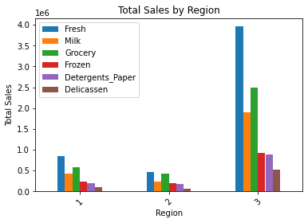

```python
# Plot total sales of different product categories by region
plt.figure(figsize=(6,7))
df.groupby('Region')[['Fresh', 'Milk', 'Grocery', 'Frozen',
       'Detergents_Paper', 'Delicassen']].sum().plot(kind='bar')

# Rotate x-axis labels for better readability
plt.xticks(rotation=45)
plt.title('Total Sales by Region')

# Set labels for x and y axes
plt.xlabel('Region')
plt.ylabel('Total Sales')

# Display the plot
plt.show()
```

## 1-4

```
Region
1    16.32
2    10.64
3    73.03
dtype: float64
```

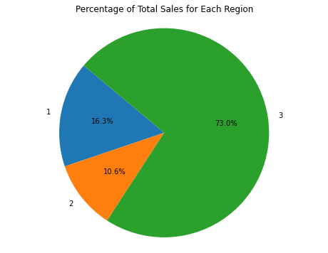

```python
# Calculate percentage of total sales for each region across all product categories
print(round(df.groupby('Region')[['Fresh', 'Milk', 'Grocery', 'Frozen',
       'Detergents_Paper', 'Delicassen']].sum().sum(axis=1) / df.sum().sum() * 100, 2))

# Pie chart for percentage of total sales for each region
plt.figure(figsize=(8, 6))
region_sales_percentage = df.groupby('Region')[['Fresh', 'Milk', 'Grocery', 'Frozen', 'Detergents_Paper', 'Delicassen']].sum().sum(axis=1) / df.sum().sum() * 100
plt.pie(region_sales_percentage, labels=region_sales_percentage.index, autopct='%1.1f%%', startangle=140)
plt.title('Percentage of Total Sales for Each Region')
plt.axis('equal')
plt.show()
```

## 1-5

```python
# Calculate percentage of total sales for each channel across all product categories
df.groupby('Channel')[['Fresh', 'Milk', 'Grocery', 'Frozen',
       'Detergents_Paper', 'Delicassen']].sum().sum(axis=1) / df.sum().sum() * 100
```

```
Channel
1    54.712120
2    45.276246
dtype: float64
```

## 1-6

```
       Channel  Region      Fresh      Milk   Grocery    Frozen  \
count   440.00  440.00     440.00    440.00    440.00    440.00
mean      1.32    2.54   12000.30   5796.27   7951.28   3071.93
std       0.47    0.77   12647.33   7380.38   9503.16   4854.67
min       1.00    1.00       3.00     55.00      3.00     25.00
25%       1.00    2.00    3127.75   1533.00   2153.00    742.25
50%       1.00    3.00    8504.00   3627.00   4755.50   1526.00
75%       2.00    3.00   16933.75   7190.25  10655.75   3554.25
max       2.00    3.00  112151.00  73498.00  92780.00  60869.00

       Detergents_Paper  Delicassen
count            440.00      440.00
mean            2881.49     1524.87
std             4767.85     2820.11
min                3.00        3.00
25%              256.75      408.25
50%              816.50      965.50
75%             3922.00     1820.25
max            40827.00    47943.00
```

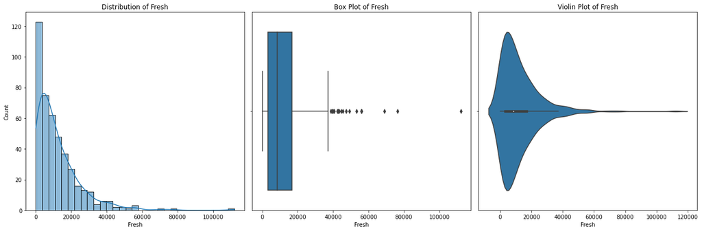

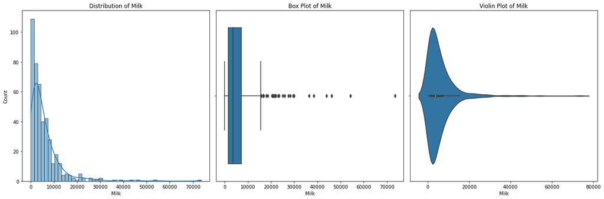

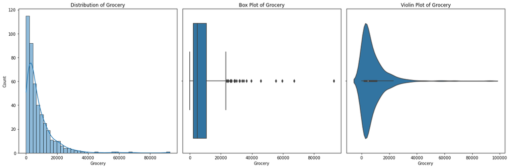

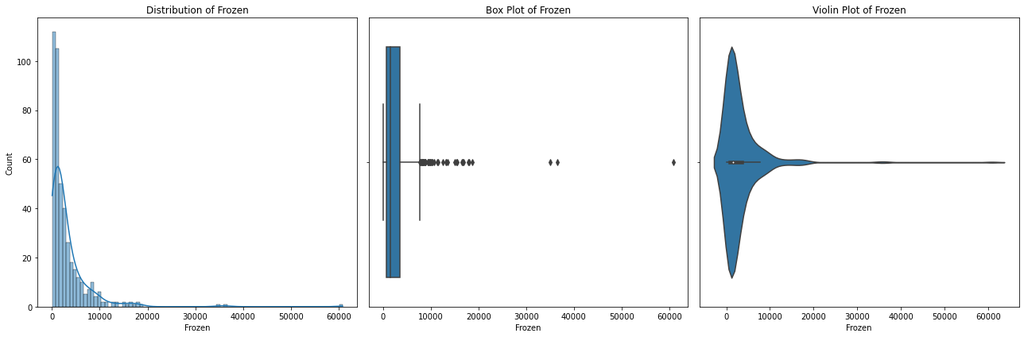

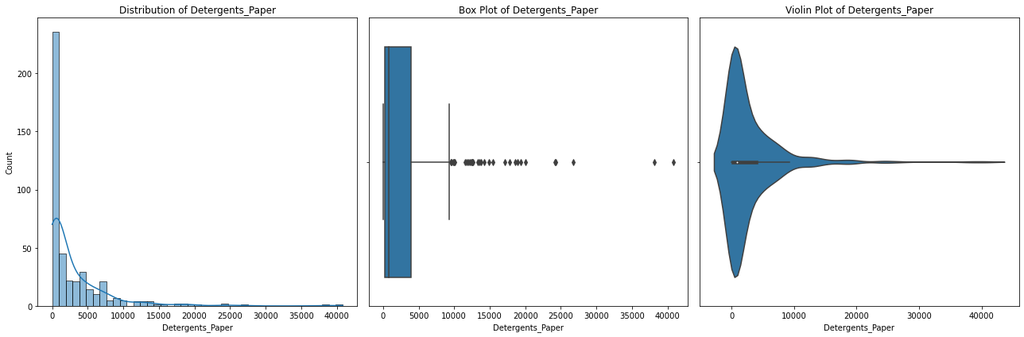

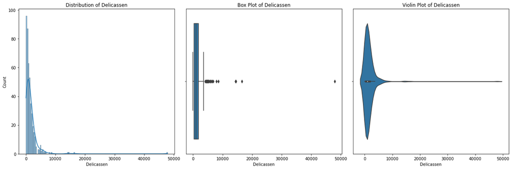

```python
# Basic descriptive statistics for each category
print(df.describe().round(2))

# Distribution Analysis with Violin Plots
for column in df.columns[2:]:
    fig, ax = plt.subplots(1, 3, figsize=(18, 6))
    sns.histplot(df[column], kde=True, ax=ax[0])
    ax[0].set_title(f'Distribution of {column}')
    sns.boxplot(x=df[column], ax=ax[1])
    ax[1].set_title(f'Box Plot of {column}')
    sns.violinplot(x=df[column], ax=ax[2])
    ax[2].set_title(f'Violin Plot of {column}')
    plt.tight_layout()
    plt.show()
```

## 1-7

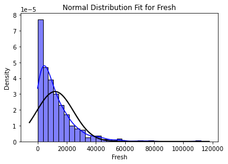

```
Normal Fit for Fresh: Mean = 12000.3, Std = 12632.95
```

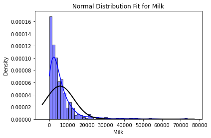

```
Normal Fit for Milk: Mean = 5796.27, Std = 7371.99
```

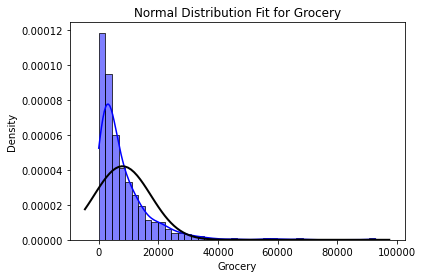

```
Normal Fit for Grocery: Mean = 7951.28, Std = 9492.36
```

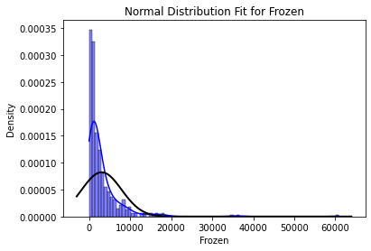

```
Normal Fit for Frozen: Mean = 3071.93, Std = 4849.15
```

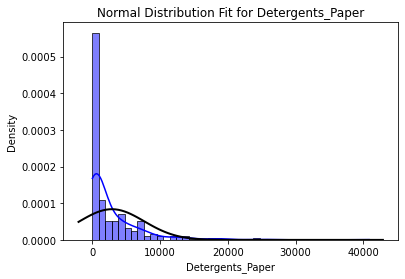

```
Normal Fit for Detergents_Paper: Mean = 2881.49, Std = 4762.43
```

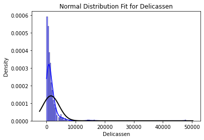

```
Normal Fit for Delicassen: Mean = 1524.87, Std = 2816.9
Expected number of purchases (lambda) for 'Frozen': 3071.93
```

```python
# Normal Distribution Fit
for column in df.columns[2:]:
    mu, std = stats.norm.fit(df[column])
    plt.figure()
    sns.histplot(df[column], kde=True, stat='density', color='blue')
    xmin, xmax = plt.xlim()
    x = np.linspace(xmin, xmax, 100)
    p = stats.norm.pdf(x, mu, std)
    plt.plot(x, p, 'k', linewidth=2)
    plt.title(f'Normal Distribution Fit for {column}')
    plt.xlabel(column)
    plt.ylabel('Density')
    plt.show()
    print(f"Normal Fit for {column}: Mean = {round(mu, 2)}, Std = {round(std, 2)}")

# Poisson Distribution for 'Frozen'
lambda_frozen = df['Frozen'].mean()
print(f"Expected number of purchases (lambda) for 'Frozen': {round(lambda_frozen, 2)}")
```

## 1-8

```
T-test for 'Fresh' between Channels 1 and 2: T-stat=3.59, P-value=0.0
```

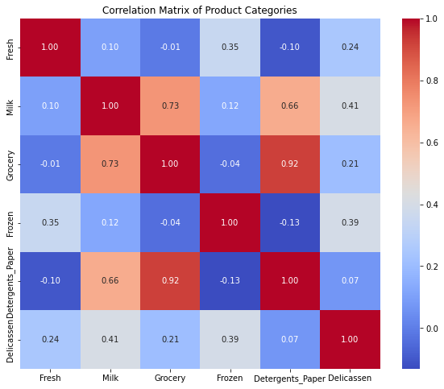

```python
# Comparing the mean spending on 'Fresh' between two channels
t_stat, p_val = stats.ttest_ind(df[df['Channel'] == 1]['Fresh'], df[df['Channel'] == 2]['Fresh'])
print(f"T-test for 'Fresh' between Channels 1 and 2: T-stat={round(t_stat, 2)}, P-value={round(p_val, 2)}")

## Correlations Between Categories
# Heatmap of Pearson correlation coefficients between product categories
plt.figure(figsize=(10, 8))
sns.heatmap(df.iloc[:, 2:].corr(), annot=True, fmt=".2f", cmap='coolwarm')
plt.title('Correlation Matrix of Product Categories')
plt.show()
```

## 1-9

```python
# Drop 'Channel' and 'Region' columns from DataFrame
df_products = df.drop(columns=['Channel', 'Region'], axis=1)
```

## 1-10

```python
# Display column names of the DataFrame for product categories
print("Columns of the DataFrame for product categories:")
df_products.columns
```

```
Columns of the DataFrame for product categories:
```

```
Index(['Fresh', 'Milk', 'Grocery', 'Frozen', 'Detergents_Paper', 'Delicassen'], dtype='object')
```

## 1-11

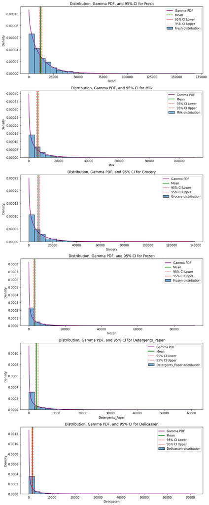

```python
# Visualize each column's data distribution, Gamma PDF, and 95% confidence intervals.

num_columns = len(df_products.columns)
fig, axs = plt.subplots(num_columns, 1, figsize=(10, num_columns*4))  # One plot per column for clarity

for idx, column in enumerate(df_products.columns):
    data = df_products[column]
    mean = np.mean(data)
    standard_deviation = np.std(data)
    shape_df = len(data)

    # Calculating the Gamma distribution parameters
    variance_gamma = standard_deviation**2
    k_gamma = mean**2 / variance_gamma  # Shape parameter
    theta_gamma = variance_gamma / mean  # Scale parameter

    # Plotting the histogram of the data
    sns.histplot(data, kde=False, ax=axs[idx], label=f"{column} distribution", alpha=0.6, bins=20, stat="density")

    # Overlaying the Gamma PDF
    x = np.linspace(0, max(data)*1.5, 1000)
    y = stats.gamma.pdf(x, a=k_gamma, scale=theta_gamma)
    axs[idx].plot(x, y, label=f"Gamma PDF", color='purple')

    # Calculating and plotting the mean and 95% confidence intervals
    standard_error = standard_deviation / np.sqrt(shape_df)
    lower = mean - 1.96 * standard_error  # For 95% confidence interval
    upper = mean + 1.96 * standard_error
    axs[idx].axvline(x=mean, color='green', linestyle='-', linewidth=2, label='Mean')
    axs[idx].axvline(x=lower, color='red', linestyle='--', linewidth=1, label='95% CI Lower')
    axs[idx].axvline(x=upper, color='red', linestyle='--', linewidth=1, label='95% CI Upper')

    axs[idx].set_title(f'Distribution, Gamma PDF, and 95% CI for {column}')
    axs[idx].legend()

plt.tight_layout()
plt.show()
```

## 1-13

$H_0 :$ There's no association between Channel sales and Regions

```python
# Define row and column labels
rowlabel = ['Channel 1', 'Channel 2']
collabel = ['Region 1', 'Region 2', 'Region 3']

# Create a cross-tabulation table
table = pd.crosstab(df['Channel'], df['Region'], margins=False, normalize=False)

# Set row and column labels
table.index = rowlabel
table.columns = collabel

# Display the table
print("Cross-tabulation of Channel and Region without normalization:")
print(table)
```

```
Cross-tabulation of Channel and Region without normalization:
           Region 1  Region 2  Region 3
Channel 1        59        28       211
Channel 2        18        19       105
```

```python
# Define row and column labels
rowlabel = ['Channel 1', 'Channel 2']
collabel = ['Region 1', 'Region 2', 'Region 3']

# Create a cross-tabulation table with normalized frequencies
prop = pd.crosstab(df['Channel'], df['Region'], margins=False, normalize=True)

# Set row and column labels
prop.index = rowlabel
prop.columns = collabel

# Display the table with rounded values
print("Cross-tabulation of Channel and Region with normalized frequencies:")
print(prop.round(2))
```

```
Cross-tabulation of Channel and Region with normalized frequencies:
           Region 1  Region 2  Region 3
Channel 1      0.13      0.06      0.48
Channel 2      0.04      0.04      0.24
```

```python
# Convert the previously created 'table' into a
# 'Table' object from statsmodels.
table = sm.stats.Table(table)

# Print the fitted values of the table. Fitted values in the context of a contingency table
# are the expected frequencies of observations for each cell of the table under the null
# hypothesis of independence between the variables. In other words, it shows what the distribution
# of 'Channel' across 'Region' would look like if there were no association between the two.
print(table.fittedvalues)

# Perform a test for nominal association between 'Channel' and 'Region'. This test evaluates
# whether there is a statistically significant association between the two categorical variables.
# The test used here is likely a Chi-squared test of independence, which is common for this type
# of analysis. The result of this test includes the Chi-squared statistic and the p-value, among
# other details.
X2 = table.test_nominal_association()

print(X2)
```

```
           Region 1   Region 2    Region 3
Channel 1     52.15  31.831818  214.018182
Channel 2     24.85  15.168182  101.981818
df          2
pvalue      0.11365689324243589
statistic   4.349142154535748
```

```python
print("Standardized residuals:")
table.standardized_resids
```

```
Standardized residuals:
```

|  | Region 1 | Region 2 | Region 3 |
| --- | --- | --- | --- |
| Channel 1 | 1.838309 | -1.264988 | -0.684097 |
| Channel 2 | -1.838309 | 1.264988 | 0.684097 |

Based on the results for the Chi-squared test, there is no dependence between the channels and the regions.

*Sales Startegy:*

- We can execute a sales strategy that is uniform across channel or region. This means that we can design a marketing campaign that is the same across all channels and regions.

## 1-14

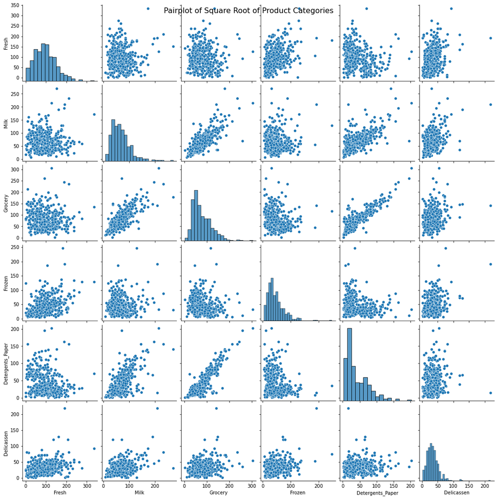

```python
# Plotting pairplot using square root of data
pairplot_fig = sns.pairplot(data=np.sqrt(df_products))
pairplot_fig.fig.suptitle('Pairplot of Square Root of Product Categories', size=16)
plt.show()
```

### Fitting Models for Prediction

## 1-15

```
Summary of the Linear Model:
                            OLS Regression Results
==============================================================================
Dep. Variable:                Grocery   R-squared:                       0.855
Model:                            OLS   Adj. R-squared:                  0.855
Method:                 Least Squares   F-statistic:                     2582.
Date:                Sun, 18 Feb 2024   Prob (F-statistic):          9.56e-186
Time:                        08:00:11   Log-Likelihood:                -4229.2
No. Observations:                 440   AIC:                             8462.
Df Residuals:                     438   BIC:                             8471.
Df Model:                           1
Covariance Type:            nonrobust
====================================================================================
                       coef    std err          t      P>|t|      [0.025      0.975]
------------------------------------------------------------------------------------
Intercept         2640.7728    201.892     13.080      0.000    2243.976    3037.570
Detergents_Paper     1.8430      0.036     50.812      0.000       1.772       1.914
==============================================================================
Omnibus:                      190.986   Durbin-Watson:                   2.056
Prob(Omnibus):                  0.000   Jarque-Bera (JB):             1474.278
Skew:                           1.680   Prob(JB):                         0.00
Kurtosis:                      11.314   Cond. No.                     6.51e+03
==============================================================================

Notes:
[1] Standard Errors assume that the covariance matrix of the errors is correctly specified.
[2] The condition number is large, 6.51e+03. This might indicate that there are
strong multicollinearity or other numerical problems.
RMSE: 3615.0755545532143
MAE: 2391.9006173403636
```

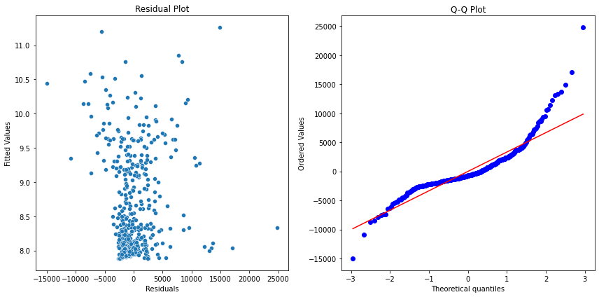

```
Feature Importance:
Intercept           2640.772792
Detergents_Paper       1.842970
dtype: float64
```

```python
# Fit Linear Model with interaction term
fitd = smf.ols(formula='Grocery ~ Detergents_Paper', data=df_products).fit()

# Print summary of the model
print("Summary of the Linear Model:")
print(fitd.summary())

print("RMSE:", np.sqrt(mean_squared_error(df['Grocery'], fitd.predict())))
print("MAE:", mean_absolute_error(df['Grocery'], fitd.predict()))

# Diagnostic Plots
fig, axs = plt.subplots(1, 2, figsize=(12, 6))
# Residual Plot
sns.scatterplot(x=fitd.resid, y=np.log(fitd.fittedvalues), ax=axs[0])
axs[0].set_title('Residual Plot')
axs[0].set_xlabel('Residuals')
axs[0].set_ylabel('Fitted Values')
# Q-Q Plot
stats.probplot(fitd.resid, plot=axs[1])
axs[1].set_title('Q-Q Plot')
plt.tight_layout()
plt.show()

# Feature Importance
feature_importance = fitd.params
print("Feature Importance:")
print(feature_importance)
```

## 1-16

```python
# Fitting a generalized linear model (GLM) with gamma distribution
fitd = smf.glm(formula='Grocery ~ Detergents_Paper + Milk',
               family=sm.families.Gamma(link=sm.families.links.identity()),
               data=df_products).fit()

# Print summary of the model
print("Summary of the GLM with gamma distribution:")
print(fitd.summary())

# Print AIC (Akaike Information Criterion)
print(f"AIC: {fitd.aic}")
```

```
Summary of the GLM with gamma distribution:
                 Generalized Linear Model Regression Results
==============================================================================
Dep. Variable:                Grocery   No. Observations:                  440
Model:                            GLM   Df Residuals:                      437
Model Family:                   Gamma   Df Model:                            2
Link Function:               identity   Scale:                         0.30160
Method:                          IRLS   Log-Likelihood:                -4071.8
Date:                Sun, 18 Feb 2024   Deviance:                       124.26
Time:                        08:00:11   Pearson chi2:                     132.
No. Iterations:                    13   Pseudo R-squ. (CS):             0.9289
Covariance Type:            nonrobust
====================================================================================
                       coef    std err          z      P>|z|      [0.025      0.975]
------------------------------------------------------------------------------------
Intercept         1186.4343    113.216     10.479      0.000     964.535    1408.334
Detergents_Paper     1.4182      0.119     11.873      0.000       1.184       1.652
Milk                 0.5022      0.054      9.324      0.000       0.397       0.608
====================================================================================
AIC: 8149.556532416005
```

*Observation:*

Based on the results of our Linear models we see that the result of the test AIC, the Gamma family showed better results in predicting groceries better than the OLS

## 1-17

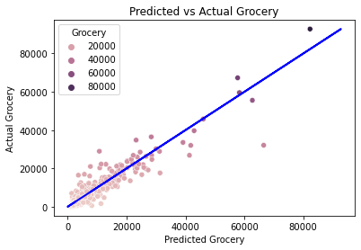

```python
# Checking predicted values against actual points
sns.scatterplot(x=fitd.predict(), y=df_products['Grocery'], hue=df_products['Grocery'])
# Line for perfect predictions
plt.plot(df['Grocery'], df['Grocery'], color='blue', linewidth=2)
plt.title('Predicted vs Actual Grocery')
plt.xlabel('Predicted Grocery')
plt.ylabel('Actual Grocery')
plt.show()
```

## 1-18

[figure not shown]

```python
# Plotting residual plot
plt.figure(figsize=(8,8))
sns.scatterplot(x=fitd.resid_deviance, y=fitd.fittedvalues, alpha =0.50)
plt.title('Residual Plot')
plt.xlabel('Deviance Residuals')
plt.ylabel('Log of Fitted Values')
plt.show()
```

*Forecasting Equation:*

$ groceries = 1186 + 1.42(Detergents/paper) + .50(Milk) Monetary Units$